# Лабораторная работа №6

Адресация IPv4 и IPv6. Двойной стек

Авдадаев Джамал Геланиевич

19 декабря 2025

# Цель работы

## Основная цель

Изучение принципов распределения и настройки адресного пространства  
на устройствах сети:

- разбиение IPv4 (VLSM)
- разбиение IPv6 (префиксы и диапазоны)
- настройка **Dual Stack** в GNS3
- проверка связности и анализ трафика (ARP / ICMP / ICMPv6)

# Dual Stack в GNS3

## Топология и именование

- Использованы:
  - VPCS: PC1–PC4
  - коммутаторы
  - маршрутизатор **FRR** (IPv4)
  - маршрутизатор **VyOS** (IPv6)
  - сервер (Dual Stack)

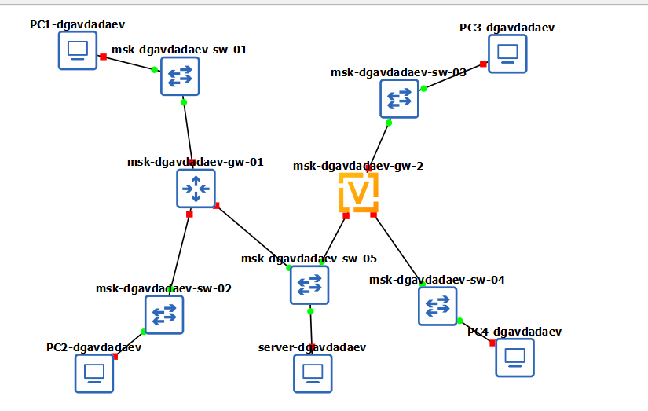

Топология в GNS3

# Настройка IPv4: конечные узлы

## Адресация (фрагмент)

- **PC1:** `172.16.20.10/25`, GW `172.16.20.1`
- **PC2:** `172.16.20.138/25`, GW `172.16.20.129`
- **Server:** `64.100.1.10/24`, GW `64.100.1.1`

[figure not shown]

IPv4 на PC1

## Проверка настройки (пример)

- корректность адреса/маски/шлюза
- сохранение конфигурации на узлах

[figure not shown]

IPv4 на PC2

# Настройка FRR (IPv4-маршрутизация)

## Конфигурация и контроль

- назначены IPv4 на интерфейсы LAN
- интерфейсы подняты
- конфигурация сохранена

[figure not shown]

Настройка FRR

## Проверка (show / состояние интерфейсов)

- адреса присутствуют
- интерфейсы активны
- маршрутизация готова к тестам

[figure not shown]

Проверка FRR

## Ping / Trace

- PC1 → PC2: ответы получены, маршрут через шлюз
- PC1 → Server: доставка успешна, межсетевой обмен корректен

[figure not shown]

PC1 ↔︎ PC2

## Доступ к серверу

- подтверждена корректная маршрутизация между подсетями IPv4

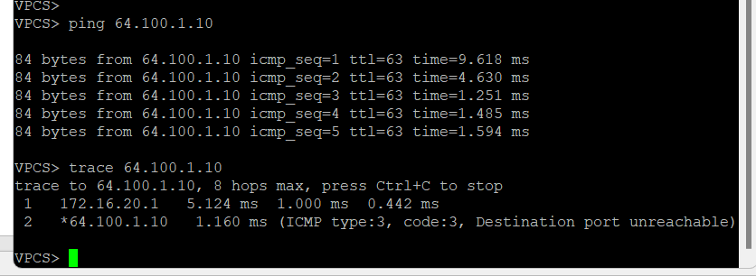

PC1 ↔︎ Server

## Назначение адресов (вручную)

- **PC3:** `2001:db8:c0de:12::a/64`
- **PC4:** `2001:db8:c0de:13::a/64`
- **Server (Dual Stack):** `2001:db8:c0de:11::a/64`

[figure not shown]

IPv6 на PC3

## Сервер в режиме Dual Stack

- IPv4 и IPv6 активны одновременно
- сервер доступен из обеих сред (при наличии маршрутизации)

[figure not shown]

IPv4+IPv6 на Server

## Настройка VyOS (IPv6-маршрутизация)

- имя устройства
- IPv6-адреса на `eth0/eth1/eth2`
- Router Advertisement для распространения префиксов в сегментах

[figure not shown]

VyOS: IPv6 и RA

## Контроль состояния

- интерфейсы активны
- IPv6-адреса назначены корректно

[figure not shown]

Проверка VyOS

## Ping / Trace

- PC3 → PC4: ответы получены, маршрут через VyOS
- PC3 → Server: доставка успешна

[figure not shown]

PC3 ↔︎ PC4

## Изоляция IPv4 и IPv6 сегментов

[figure not shown]

Изоляция и доступ к Dual Stack

## ARP (IPv4)

- разрешение `IP → MAC` в канальном сегменте
- пример: запрос от шлюза `64.100.1.1` к серверу `64.100.1.10`
- подтверждает L2-соседство и работу шлюза

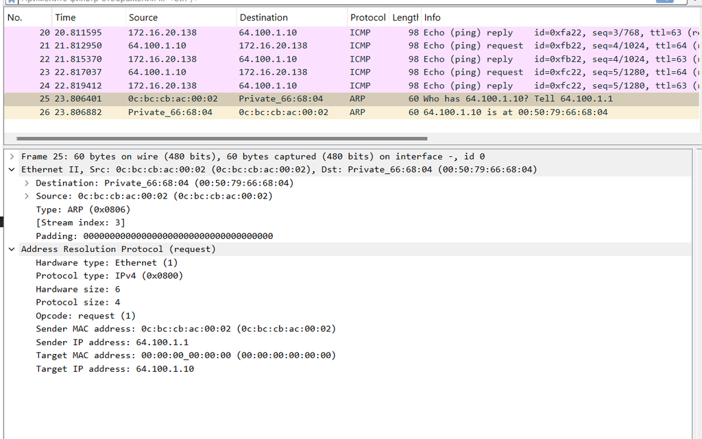

ARP-трафик

## ICMP (IPv4)

- Echo Request / Reply
- по TTL видно прохождение маршрутизатора
- подтверждает корректную маршрутизацию IPv4 между подсетями

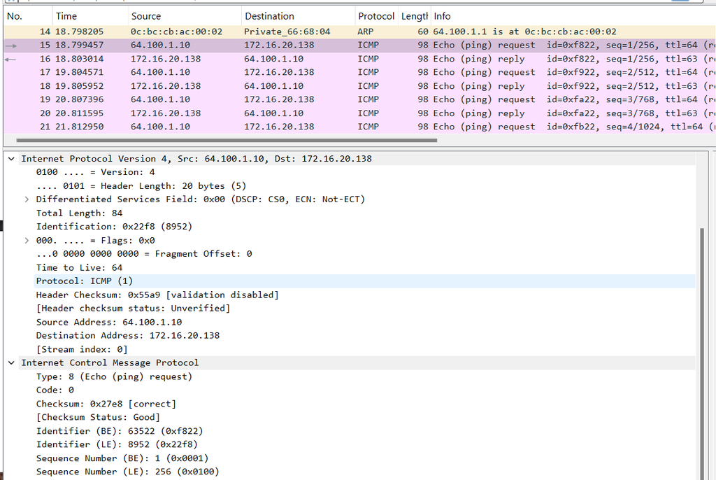

ICMP-трафик IPv4

## ICMPv6 (IPv6)

- Echo Request / Reply (диагностика)
- Neighbor Solicitation / Advertisement (аналог ARP)
- Hop Limit — аналог TTL

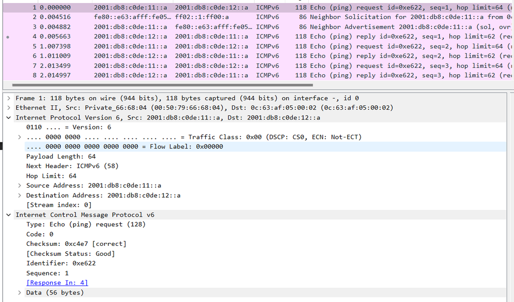

ICMPv6-трафик

# Самостоятельное задание (2 подсети)

## Адресное пространство

- Подсеть 1:
  - IPv4: `10.10.1.96/27` (30 хостов)
  - IPv6: `2001:db8:1:1::/64`
- Подсеть 2:
  - IPv4: `10.10.1.16/28` (14 хостов)
  - IPv6: `2001:db8:1:4::/64`

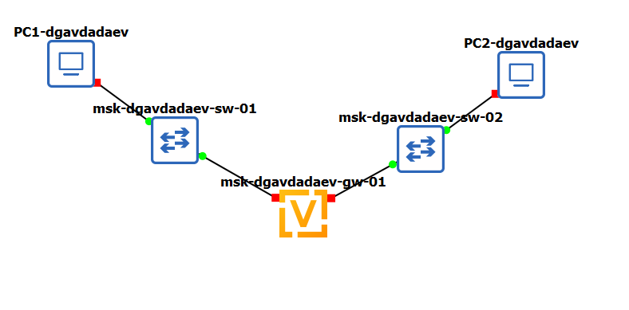

Топология (самост.)

## Таблица адресации (минимальные адреса для роутера)

- Router / Subnet 1:
  - IPv4 `10.10.1.97/27`
  - IPv6 `2001:db8:1:1::1/64`
- Router / Subnet 2:
  - IPv4 `10.10.1.17/28`
  - IPv6 `2001:db8:1:4::1/64`
- PC1:
  - IPv4 `10.10.1.100/27`, GW `10.10.1.97`
  - IPv6 `2001:db8:1:1::a/64`
- PC2:
  - IPv4 `10.10.1.20/28`, GW `10.10.1.17`
  - IPv6 `2001:db8:1:4::a/64`

## Проверка связности (IPv4/IPv6)

[figure not shown]

Ping/Trace IPv4

# Итоги работы

## Выводы

- Выполнено разбиение IPv4 и IPv6 сетей с расчётом диапазонов
- Настроен **Dual Stack**-сервер и маршрутизация:
  - FRR для IPv4
  - VyOS для IPv6 (+ Router Advertisement)
- Подтверждена связность и корректная маршрутизация
- Проанализированы:
  - ARP (IPv4)
  - ICMP (IPv4)
  - ICMPv6 + Neighbor Discovery (IPv6)